# Evaluación curso R

Gemma García Lluch

## Entrega

- Recuerda completar tu **nombre en el apartado author**.
- Además del código, no olvides completar las respuestas a las preguntas indicadas en negrita.
- Si tienes dudas/dificultades, **puedes contactar con los profesores**.
- Deadline: **viernes 10 de junio, 23:59**.
- Puedes realizar la entrega en el mail: **constantino.garciama@ceu.es**.
- La entrega consistirá en este fichero rellenado y el fichero que se genera al hacer `Knit` (un fichero `Rmd` y un fichero `html`).

## Apuestas de adolescentes en UK

El conjunto de datos `teengamb.csv` contiene datos sobre las tasas de juego entre los adolescentes en Gran Bretaña, su género y estatus socioeconómico. Una pregunta que nos puede interesar es cómo se relacionan el género y los ingresos con cuánto juega una persona (céntrate solo en las variables `income`, `sex` y `gamble`)… Sigue los siguientes pasos para crear un ANCOVA…

### 1) Carga y visualiza los datos…

…para valorar si el modelo debe incluir interacciones. Escribe claramente tus conclusiones

```r
knitr::opts_chunk$set(echo = TRUE)
(c("tidyverse", "afex", "emmeans", "GGally", "effectsize", "performance", "see", "qqplotr"))
```

```
## [1] "tidyverse"   "afex"        "emmeans"     "GGally"      "effectsize"
## [6] "performance" "see"         "qqplotr"
```

```r
library("tidyverse")
theme_set(theme_bw())
teengamb <- read.csv("~/Desktop/Curso Programación con R Mayo2022/Material evaluación/MATERIAL EVALUACIÓN/teengamb.csv")

teengamb
```

```
##       sex status income verbal      gamble
## 1  Female     51   2.00      8  20.9658052
## 2  Female     28   2.50      8 -11.0915144
## 3  Female     37   2.00      6  -8.5867626
## 4  Female     28   7.00      4  17.3517324
## 5  Female     65   2.00      8 -17.2524094
## 6  Female     61   3.47      6  14.8785327
## 7  Female     28   5.50      7 -20.7981197
## 8  Female     27   6.42      5 -15.7438197
## 9  Female     43   2.00      6  12.1798893
## 10 Female     18   6.00      7  -4.0634685
## 11 Female     18   3.00      6  24.2939832
## 12 Female     43   4.75      6  -2.6985100
## 13 Female     30   2.20      4   0.9663439
## 14 Female     28   2.00      6  -1.8934788
```

[output cut: 33 more lines]

```r
summary(teengamb)
```

```
##      sex                status          income           verbal
##  Length:47          Min.   :18.00   Min.   : 0.600   Min.   : 1.00
##  Class :character   1st Qu.:28.00   1st Qu.: 2.000   1st Qu.: 6.00
##  Mode  :character   Median :43.00   Median : 3.250   Median : 7.00
##                     Mean   :45.23   Mean   : 4.642   Mean   : 6.66
##                     3rd Qu.:61.50   3rd Qu.: 6.210   3rd Qu.: 8.00
##                     Max.   :75.00   Max.   :15.000   Max.   :10.00
##      gamble
##  Min.   :-33.5960
##  1st Qu.: -0.8695
##  Median : 17.7230
##  Mean   : 21.4473
##  3rd Qu.: 35.0519
##  Max.   : 88.4473
```

```r
library("GGally")
```

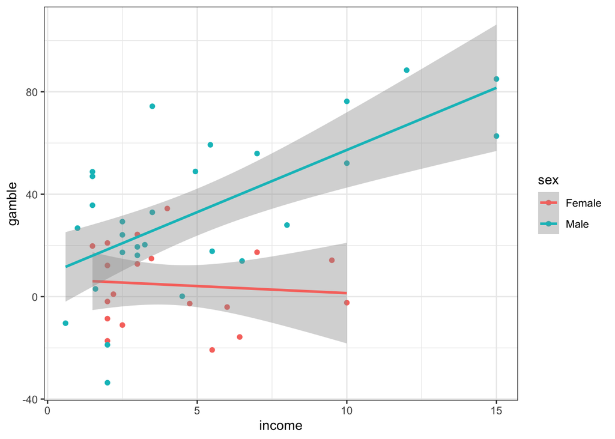

```r
ggplot(teengamb, aes(x = income, y = gamble, col = sex)) +
  geom_point() +
  geom_smooth(method="lm")
```

**Conclusiones sobre la necesidad de interacción**: Vemos que el modelo presenta líneas no paralelas, por lo que presenta interacciones. Del mismo modo, se observa como los hombres de mayores ingreosos tienden a apostar más, produciéndose el efecto contrario en las mujeres (por llo general).

### 2) Crea el modelo…

… y obtén:

- los intervalos de confianza para los coeficientes y su significación.
- Obtén los tamaños de los efectos.

```r
lm(gamble ~ income * sex, teengamb)
```

```
##
## Call:
## lm(formula = gamble ~ income * sex, data = teengamb)
##
## Coefficients:
##    (Intercept)          income         sexMale  income:sexMale
##         6.8743         -0.5489          1.8427          5.4050
```

```r
modelo1=lm(gamble ~ income * sex, data=teengamb)
confint(modelo1)
```

```
##                     2.5 %    97.5 %
## (Intercept)    -11.769152 25.517839
## income          -4.385455  3.287728
## sexMale        -20.733425 24.418773
## income:sexMale   1.082260  9.727751
```

```r
library("effectsize")

effectsize(modelo1)
```

```
## # Standardization method: refit
##
## Parameter      | Std. Coef. |         95% CI
## --------------------------------------------
## (Intercept)    |      -0.59 | [-0.93, -0.25]
## income         |      -0.07 | [-0.54,  0.40]
## sexMale        |       0.93 | [ 0.49,  1.37]
## income:sexMale |       0.66 | [ 0.13,  1.19]
```

[output not shown]

### 3) Interpreta los coeficientes y escribe tus conclusiones.

**Conclusiones sobre las variables de interés**:

### 4) Crea un gráfico con las predicciones de tu modelo…

…y compáralas con los datos reales.

```
## No summary function supplied, defaulting to `mean_se()`
## No summary function supplied, defaulting to `mean_se()`
```

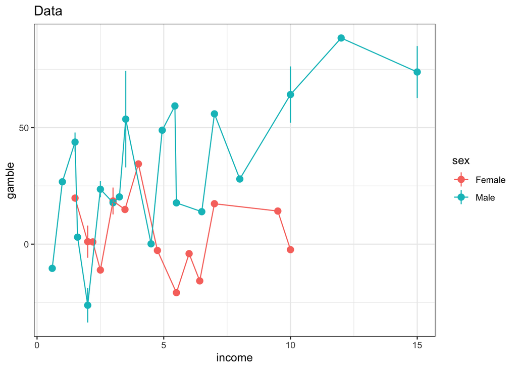

```r
ggplot(modelo1, aes(x=income, y=gamble, col=sex)) +
  stat_summary() +
  stat_summary(geom='line', aes(group=sex)) +
  ggtitle("Data")
```

```r
library(emmeans)
gamble ~ income * sex
```

```
## gamble ~ income * sex
```

```
## No summary function supplied, defaulting to `mean_se()`
## No summary function supplied, defaulting to `mean_se()`
```

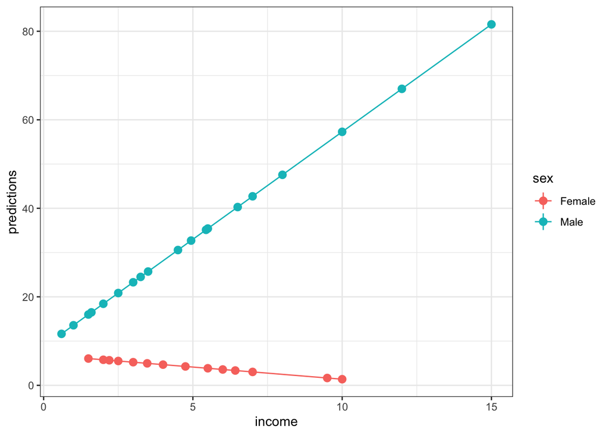

```r
modelo1=lm(gamble ~ income * sex, data=teengamb)
teengamb$predictions=predict(modelo1)
ggplot(teengamb, aes(x=income,y=predictions,col=sex))+stat_summary()+stat_summary(geom = 'line',aes(group=sex))
```

```r
#A partir del modelo preodictivo, y en general, se observa una mayor tendencia de los hombres de mayores ingreos a apostar más, produciéndose el efecto contrario en las mujeres.
```

**¿Es bueno el ajuste?:** En general, el ajuste es bueno

### 5) Valora si las asunciones del modelo se cumplen

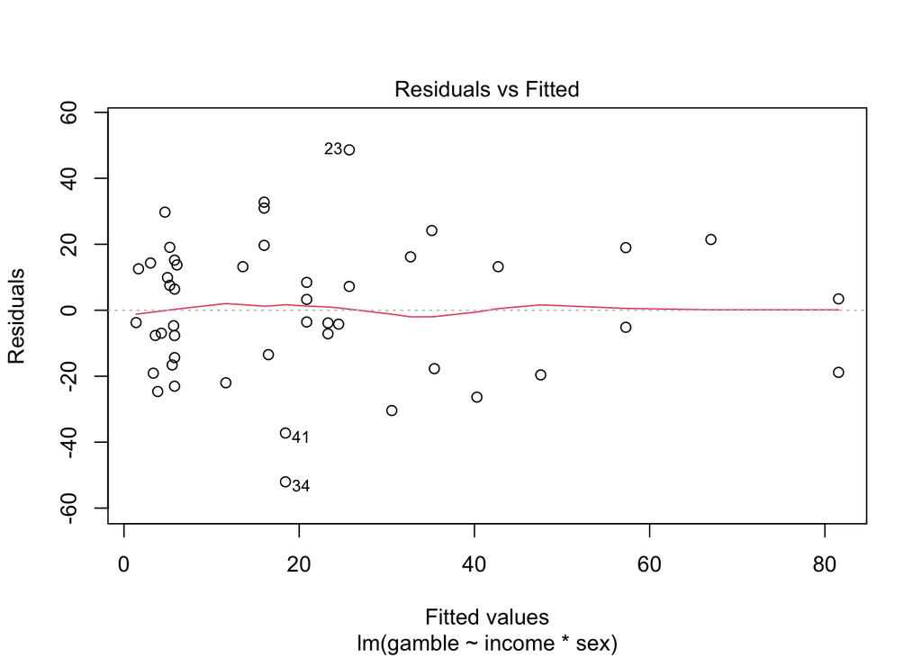

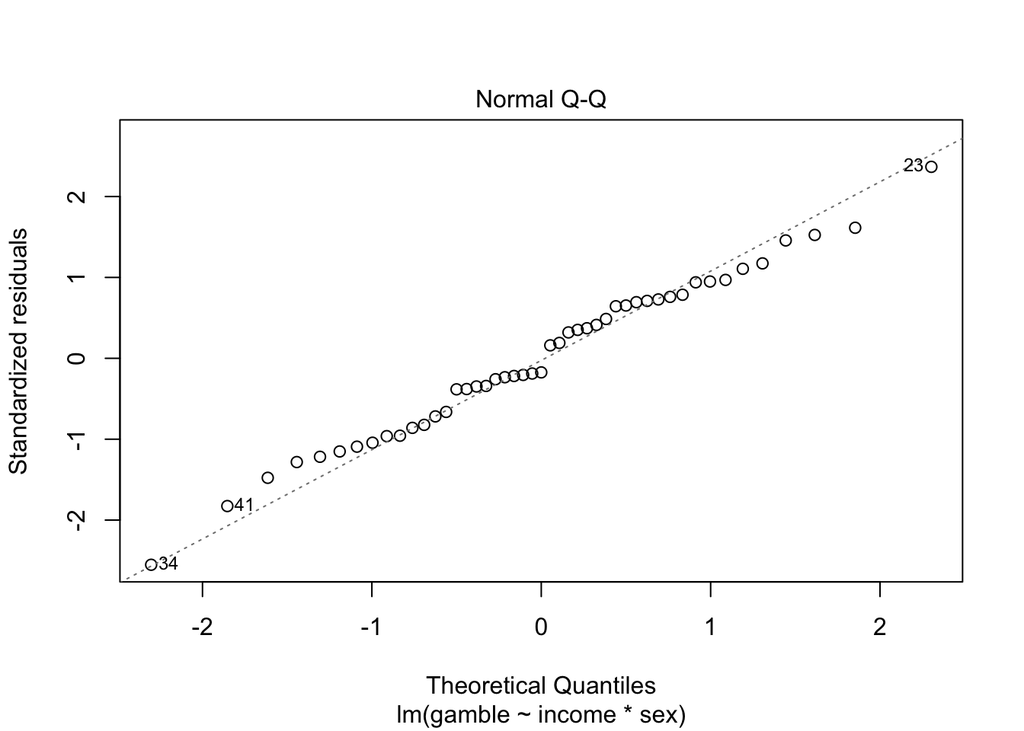

```r
plot(modelo1, which = c(1, 2), ask=FALSE)
```

**¿Es el modelo correcto?:** En el gráfico de residuales observamos que los valores reales están algo alejados de la línea teórica, existiendo uan desviación de +-40. Sin embargo, en la gráfica de los residuales estandarizados comprobamos que los valores reales están en la línea teórica, por lo que podemos concluir que el modelo es correcto.